# 文件夹名改变了 agent 先用哪个语言算题

工作目录名里换一个词，题面不作任何语言提示 · 288 次试次

发布于

2026年11月12日

## 1 摘要

**工作目录的名字会改变 agent 第一步用哪个语言算题。** 目录名取 R 包名（`dplyr`、`ggplot`、`purrr`）时，42% 的试次第一步就用 R 计算；换成不指向任何语言生态的真实软件项目名（`kafka`、`nginx`、`prometheus`）时，该比例降至 15%。两者相差 26 个百分点（41.7% 对 15.3%），按名字的随机化检验 p = 0.0002，每组 12 个名字、每个名字 6 次。

换用不含任何指向的英文姓氏作对照，差值为 19 个百分点，p = 0.0047；这是更保守的估计，因为上一组的沉默率更高，会放大差值（3.1）。题面、工具、系统提示词全程未变，唯一改动是目录名；而目录名不是 agent 主动去读的——编排器在它第一次输出之前就把完整路径注入上下文，288 条试次无一例外。

一个无人要求读取的字符串，稳定改变了 agent 第一次调用哪个运行时。因此任何”模型倾向某语言”的评测结论，都须先报告它当时的工作目录叫什么名字。

## 2 研究设计

### 2.1 一次试次

给 agent 一个空目录，目录名为 `dplyr-03`，里面放一道题：用 NIST 的 Norris 数据做一次最小二乘拟合，报出六个量：截距、斜率、$R^2$、残差标准差、两个标准误。用什么算由它决定：写脚本、敲命令、直接心算都可以，题面不提示任何语言。

观测的只有一件事：**它第一次动手计算时，调用的是哪个语言。** 同一道题，目录名为 `dplyr-03` 时它多半调用 R，为 `kafka-03` 时多半调用 Python；题面与工具完全没有改动，唯一的变化是目录名。

这里要说清目录名是**怎么到的**，因为它决定了结论该怎么读。目录名不是 agent 主动去读的：编排器在它第一次输出之前，用 user 消息把工作目录送进上下文——一条 runtime-context 快照，一条工作目录变更通知。本研究 288 条试次全部带这两类消息，槽位名在注入文本里出现两次，一次来自各条消息（`msg_kinds` 列），一次来自计数（`cwd_mentions` 列恒为 2）。所以题面确实不要求读它，**但运行时主动送达，模型在看到题面之前就已经拿到完整路径**。

这两种说法对应的结论强度不同。如果线索是 agent 主动去翻的，可以说它有多探索的倾向；实际情形是线索被塞进来，那么结论就落在评测上：**靠”不要求模型读目录名”消不掉这个线索**，因为送不送由运行时决定，不由题面决定。

### 2.2 处理：目录名里放什么

被操纵的变量只有一个：目录名是否属于 R 生态。四组名字的作用是把这一变量孤立出来。48 个目录名分为四组，每组 12 个：

| 组 | 名字是什么 | 在该批中的角色 |
| --- | --- | --- |
| `r-eco` | R 包的名字（`dplyr` `ggplot` `knitr` `purrr`） | 处理组：指向 R 生态 |
| `software` | 独立软件项目的名字（`kafka` `nginx` `consul` `etcd`） | **控制组：排除「它只是像软件名」这一解释** |
| `py-eco` | Python 包的名字（`pandas` `polars` `sklearn` `sympy`） | 反向对照：指向 Python 生态 |
| `plain` | 英文姓氏（`ashby` `marlow` `orwell` `radley`） | 基线：名字不含任何指向 |

组内使用 12 个不同的名字，而非同一个词重复 12 次。名字的数量决定结论能覆盖的范围：只用 1 个词，结论只能是”`tidyverse` 这个词有效”；用 12 个语义等价而字面不同的名字，结论才能覆盖”这一类名字”。

### 2.3 为什么要用「也像软件名」的对照组

检验”名字指向 R 生态是否有影响”之前，必须先排除一个替代解释：

> 模型也许并非被 R 打动，而是被”名字看起来像某个软件项目”打动；见到软件名就更容易动手写代码，与 R 无关。

这种解释之所以站得住，是因为 `r-eco` 组的名字本身就是软件名：R 包属于软件，`dplyr` 是真实存在的软件项目。因此对照组必须同样由真实的软件项目名构成：`software` 组用的是 `kafka`、`nginx`、`consul` 这类独立软件项目的名字，不折不扣的软件名，但不指向任何语言的生态。`plain` 组更远一步，用英文姓氏，既不形似软件项目，也不指向任何语言，给出的是”名字不含任何指向时，基线在什么位置”。

| 名字的类型 | 指向 R 生态 | 指向 Python 生态 | 不指向任何语言生态 |
| --- | --- | --- | --- |
| **真实软件项目的名字** | **`r-eco`** | `py-eco` | `software` |
| **英文姓氏** | — | — | `plain` |

主对比估计的量是：

$$\Delta = P(\text{用 R} \mid \text{r-eco}) \;-\; P(\text{用 R} \mid \text{software})$$

一处需要交代的操作细节：“指向 R”在具体选词上就落成了”是一个 R 包的名字”。R 生态里几乎所有的名字都以包的形式存在，没有别的形式可用，所以处理在字面上同时是”一个可安装库的名字”，这两者在本设计里无法拆开，也不存在一个”指向 R 但不是包名”的天然对照组。这不影响”这个名字指向 R 生态”这一读法，但值得记下来。

### 2.4 结局：怎么记「用了哪个语言」

解题过程中模型会多次调用工具。此处**运行时**指 R 与 Python 两个解释器；若一次调用的命令文本中出现 `Rscript` 或 `python` 等字样，则记为”点名了运行时”。取其中按时间顺序最靠前的一次，记录它点名的是哪个：

**`R`**

最早一次点名运行时的调用用的是 R

**`Python`**

同上，用的是 Python

**`未点名`**

全程没有一次调用点出任何运行时，它可能直接心算了

两点说明。其一，**只取最早一次**：该读数回答”它先想到哪个”，不回答”它最终用了哪些”，后者是另一个问题，见第 5 节。其二，**“未点名”是合法结果，而非坏数据**：该结果记为”未选 R”，保留在分母中；剔除它等同于对一项在结果之后才发生的行为取条件，会使比较失去意义。

### 2.5 规模与匹配

288 次试次由 4 组、每组 12 个名字、每个名字 6 次组成。

- **每个名字 6 次。** 若只做 3 次，单个名字的比率只能取 0、1/3、2/3、1，检验会被大量并列值削弱分辨率。
- **12 个名字。** 能测出多大效应主要取决于名字的多样性，而非重复次数：8 个名字对中等效应的把握约 0.61，12 个升至 0.80，16 个为 0.88，收益不抵成本。

另一项干扰已对齐：48 个名字作为路径时，长度全部恰为 11 个 token[^1]。否则”R 的名字更长、更醒目”会构成替代解释。

### 2.6 必须保持不变的东西

“只有名字在变”这一声明必须落到具体清单上。全程固定不变的有六项：

1. 题面
2. 输出格式
3. 系统提示词
4. 工具清单
5. 工作区模板
6. 执行顺序

证明它们确实未变的过程见第 6 节。

## 3 结果

| 组 | 第一步用了 R | 比例 |
| --- | --- | --- |
| `r-eco` | 30 / 72 | **42%** |
| `software` | 11 / 72 | **15%** |
| **差** |  | **26 个百分点** |

这就是 2.3 节定义的 Δ：

$$\Delta = \frac{30}{72} - \frac{11}{72} = 0.2639$$

p 值的算法是：假定 24 个名字本无分组，将其随机分成各 12 个的两组，统计有多少种分法能造出同样大或更大的差距。270 万种分法全部枚举完毕，其中 658 种达到。这个 p 值的前提是零假设下 24 个名字可交换；词频、熟悉度等属性并未匹配（见第 8 节），所以它支持的是”这批名字的分组不是随机划分”，而不是”只有语言这一项在起作用”。

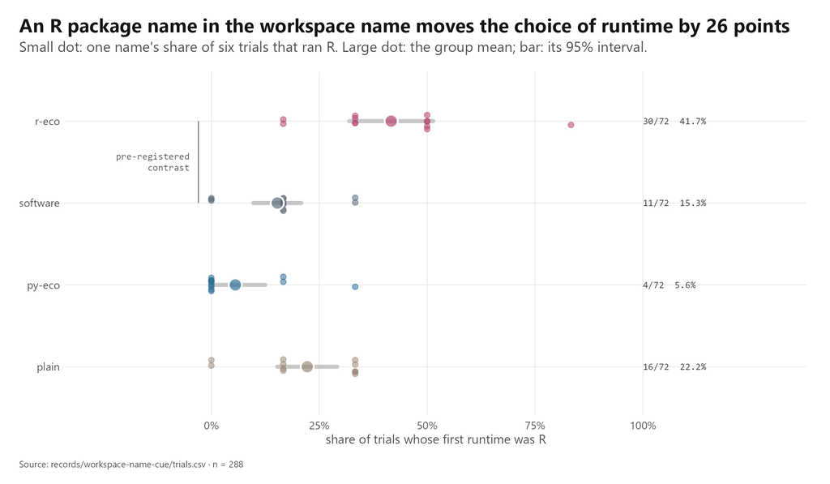

图 1: 每个小点是一个目录名的成绩：六次试次里有几次用 R；大圆点是该组平均，灰条是它的 95% 区间。

最上面两行之间的距离即 26 个百分点；下面两行是同一条坐标轴上的另外两个参照。

### 3.1 区间与更保守的下界

区间按**名字**聚类重抽样：每次从 `r-eco` 的 12 个名字、`software` 的 12 个名字里各抽 12 个（有放回），算一次均值差，重复一万次，取 2.5% 与 97.5% 分位。重抽单位是名字而不是试次——按试次重抽等于把同一名字下的 6 次当成 6 份独立证据，区间会假性变窄，这正是随机化检验按名字做的同一个理由。结果是 $95\%$ 的区间 $\Delta \in [0.153,\ 0.389]$，一万次中**没有一次**落在零以下。

对照组的行为差异会放大这个差。`software` 组有 12 次全程没有点名任何运行时，`r-eco` 组 7 次，`plain` 组 4 次：

| 组 | 全程未点名 | 占比 |
| --- | --- | --- |
| `software` | 12 / 72 | 16.7% |
| `r-eco` | 7 / 72 | 9.7% |
| `plain` | 4 / 72 | 5.6% |

按规则，“未点名”计入”未选 R”，所以 `software` 更高的沉默率会压低自己的 R 比例。更保守的对照是 `r-eco` 对 `plain`，同一个量以 `plain` 为基线：$\Delta_{\text{plain}} = 30/72 - 16/72 = 0.1944$，p = 0.0047，仍然显著。

**重要**

**保守的下界是 19 个百分点。** 26 个百分点里，超出 19 的那部分与对照组的沉默率分不开。

## 4 另外三种解释

面对 26 个百分点的差距，还需排除三种最可能的替代解释，各用一张图。

### 4.1 会不会只是一个名字碰巧

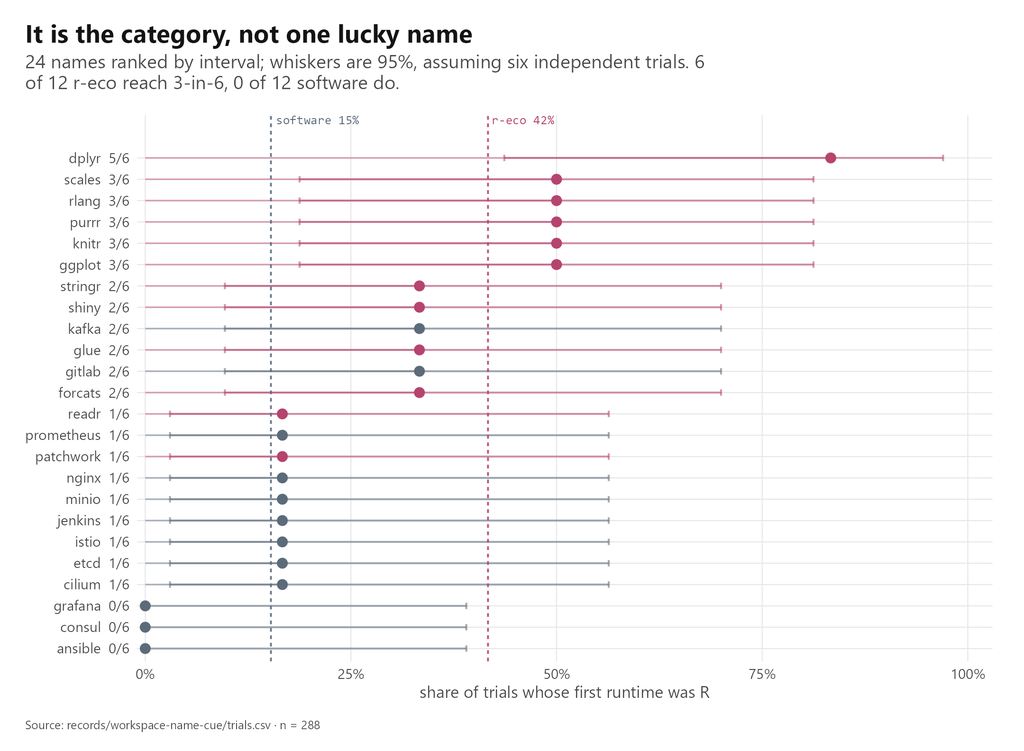

图 2: 每个名字一行。圆点是它六次试次里用 R 的比例，左右短须是该比例的 95% 区间。

如果效应由单个”幸运”名字造成，该名字应明显孤立于顶端；实际情况是 R 一侧整体偏高。更直接的证据：`r-eco` 的 12 个名字中有 **6 个**在六次中至少三次调用 R，`software` 的 12 个中一个都没有。但不宜过度解读，除 `dplyr` 外其余名字的区间重叠明显，结论因此落在”这一类名字”上，不落在”哪个名字更有效”上。

### 4.2 会不会是某一段跑偏了

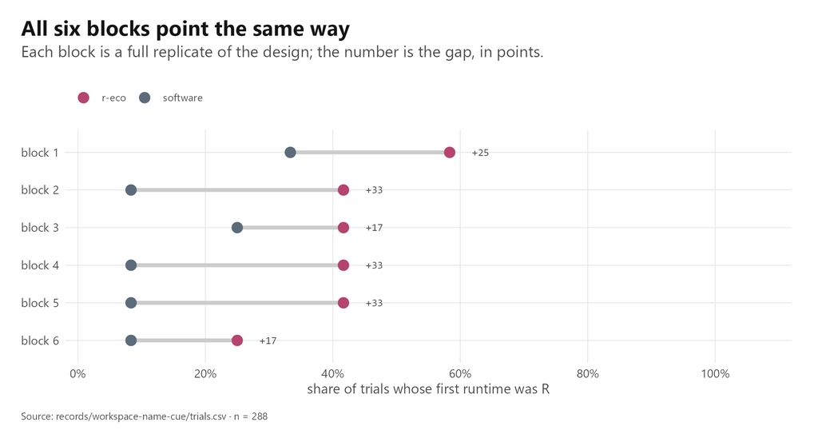

图 3: 每行一轮。两个圆点是该轮两组的比例，右侧数字是本轮差值（百分点）。

288 次分为六轮，每轮 48 次，覆盖四组、每个名字各一次。六轮方向全部一致，差距在 +17 到 +33 点之间。

### 4.3 会不会只是更卖力

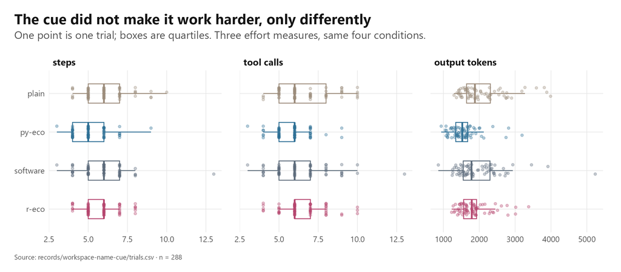

图 4: 每点一次试次，箱体是中间一半的范围。

一个只让模型更用功的线索同样能抬高 R 的比例，而不需要它对 R 有任何偏好。步数、工具调用数、输出字数三项，四组的中位数几乎重合：没有更用力，只是不同。

## 5 效应性质：加一步，还是换语言

第 3 节报告的 26 个百分点只统计**最早那次点名**用了哪个运行时，没有回答一个关键问题：用 R 的那些试次，是不是只用 R？如果 R 出现时 Python 也总在场，那这个名字做的就不是”换语言”，而是”多试一个”；两种情形在”第一步用 R 的比例”上完全一样，含义却相反。本节反复用一个说法，先定义清楚：**最早点名 R 的试次**，指按时间顺序第一次在命令文本里写出 `Rscript` 之类字样的那次调用用的是 R，它只说”先想到 R”，不说最终用谁算完。

按整个试次点名过哪些运行时分类：

| 这次试次点名了哪些运行时 | 次数 | 占比 |
| --- | --- | --- |
| 只有 R | **5** | 1.7% |
| R 与 Python 都点名了 | **57** | 19.8% |
| 只有 Python | 201 | 69.8% |
| 一个都没点名 | 25 | 8.7% |

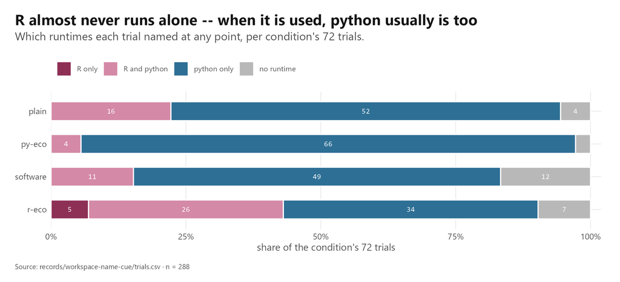

图 5: 四行是四组各 72 次试次；每一段是这些试次里点名过的运行时组合。深红只在 r-eco 那一行出现。

288 次里，R 只身出现只有 5 次，而且全部在 `r-eco` 组；其余 57 次用到 R 的试次，都同时点名了 Python。换个切法看同一件事：

$$\begin{aligned}
P(\text{又点名 Python} \mid \text{最早点名 R}) &= 56/61 = 92\% \\
P(\text{又点名 R} \mid \text{最早点名 Python}) &= 1/202 = 0.5\%
\end{aligned}$$

因此目录名里的这个词做的是**把 R 加进候选**，而不是替换语言：模型多做一个动作。

**警告**

本设计记录的是”点名了哪些运行时”，没有记录最后用哪个运行时把题算完。所以数据支持”更可能先试 R”，不支持”改用 R”，也不支持”主语言换了或没换”——最后这一句需要另一个结局定义，这批数据里没有。

## 6 怎么证明只有名字在变

第 2.6 节列出了六项固定内容。声明不变并不等于确实未变，必须逐项验证；可信度全部来自这一组检查。

### 6.1 交付的字节

每开启一次试次，题面、输出格式、系统提示词、工具清单都需要重新提交给**编排器**（负责跑批的调度程序）一份：无法按引用传递，只能重打。每重打一次就多一次漂移机会，而漂移是静默的——内容看起来一致、程序不会报错，只有编排器自己计算的**哈希指纹**[^2]会变。因此：

1. 不采用项目自己的哈希，改用编排器自报的两项指纹（工具清单、系统提示词）；
2. **每 12 次试次比对一次**，而非跑完再查；
3. 任一指纹发生变化，该组丢弃重跑。

实测中两项指纹全程各自只有一个取值（`6218479a`、`75222986`）。12 次的比对间隔来自一次教训：曾有一次漂移直到第 28 条试次才被发现。

### 6.2 宿主环境

编排器会在每次对话开头插入一条”当前所在目录”的通知，正文形如：

```
The working directory changed from "<操作者会话根>" to "<槽位目录>"
```

前半段是操作者自己的会话根路径，本例中为 `D:\RDirectory\harness-assay`，而 `RDirectory` 里就有一个 R；它随每一条试次抵达，是没人声明过的污染。要清掉的正是这前半段，后半段的槽位目录名必须原样保留，那是处理本身。处置方式是补丁把上一级目录字段改写掉，跑完逐字节还原成原装文件，并断言还原后与 npm 原件完全相等。另有一条独立通道（运行时上下文里的 `Current working directory`）始终带着槽位名，所以清掉前半段不影响暴露。

这也是为什么”只改目录名”这句话需要额外检查：处理确实只有一处，但泄漏有两处，只有一处是设计的一部分。

### 6.3 执行顺序

288 次按”每轮每个名字各一次”交错排列，而非一组跑完再跑下一组；否则”第 200 条比第 20 条更疲劳”这一效应会与组别混在一起。实测实际启动顺序与计划顺序完全一致（秩相关 +1.000，即两份排序逐项吻合），这是测量结果，不是假设。

### 6.4 丢弃规则

规则在开跑之前写入：只允许因工具链故障丢弃，不允许因结果不理想丢弃。本批实际丢弃两次，均为工具链故障，没有一条进入分析：

| 故障 | 现象 | 怎么发现 |
| --- | --- | --- |
| 工具集未被密封 | 一个参数放错层级、被静默忽略，agent 看到的是编排器的全部工具，而非设计的四个 | 装配指纹变化，而配置指纹未变 |
| 输出属性键序漂移 | 内容完全相同，只是属性顺序不同 | 指纹与首条不一致 |

之所以写明，是因为若对”丢弃过数据”只字不提，读者无从判断是否丢弃了不该丢弃的部分。

## 7 全部六种配对

四个条件两两组合共六对，全部计算。每对只检验一个结局，且是该对能够区分的那个结局；若每对在所有结局上都检验一遍，就有了挑选结果的空间。

| 对比 | 检验的结局 | 差 | p | 说明 |
| --- | --- | --- | --- | --- |
| `r-eco` vs `software` | 用 R | +0.2639 | 0.0002 | 预注册的主判定 |
| `r-eco` vs `py-eco` | 用 R | **+0.3611** | < 0.0001 | 只差语言归属 |
| `py-eco` vs `software` | 用 Python | +0.2361 | 0.0001 |  |
| `r-eco` vs `plain` | 用 R | +0.1944 | 0.0047 | 保守下界 |
| `py-eco` vs `plain` | 用 Python | +0.1944 | 0.0020 |  |
| `software` vs `plain` | 使用了任一运行时 | −0.1111 | 不检验 | 结局未声明 |

六对里五对给出 p 值。若按 Bonferroni 乘以比较次数 6：主对比 $6 \times 0.0002 = 0.0012$，`r-eco` vs `plain` 为 $6 \times 0.0047 = 0.0282$，没有一对因校正而翻转。

`r-eco` vs `py-eco` 是唯一只在语言归属上不同的对比：两侧都指向一个语言生态、都是软件项目的名字。它给出最大差值，不过要读得克制——`py-eco` 的 R 率只有 5.6%，贴近地板，差值大有一部分来自地板效应。若效应仅来自”是真实的软件项目名”，`software` vs `plain` 在”是否使用运行时”上应当为正；实际为 −0.1111，软件名反而让模型更少动手，这与主对比的解释直接相关（见3.1）。最后一行未给出 p 值，因为该结局不在事先声明的范围内。

## 8 局限

以下五条均为如实报告，而非需要消除的问题。

1. **只有一个模型。** Python 的训练语料远多于 R，该先验与线索本身在同一模型内无法分离。要分离只能换一个语料构成不同的模型重做，这是待办事项，不是已解决的问题。
2. **词频无法匹配。** `dplyr` 在英语中的罕见程度远高于 `marlow`，且无从匹配。这削弱的是”只有语言这一项不同”的因果读法。
3. **`py-eco` 已达 92%，接近上限。** 该组结果不能说明”Python 线索无效”，只说明可用空间已耗尽。
4. **六次重复的信息量有限。** 单个名字的区间较宽，这是以精度换取”这一类名字”的覆盖范围。
5. **结局只覆盖”最早一次点名”。** 最终以哪个运行时完成计算没有记录，所以结论限于”先调用哪个”，不能外推到”解题主语言”。

还有一类性质不同的问题，需要单独说明而不适合并入上面五条：编排器预设的人格提示要求”保留 4 位有效数字”，而题面要求 6 位。两者都属于系统提示词，改动任何一处都会使已完成的 288 次试次变成另一个条件。实测未造成差异（282 条通过，其余 6 条未交出结构化答案，与位数无关），因此这一矛盾被登记为常量并记录在案，而不是被修正。

## 9 这个结果的意义

一个无人要求它读取的字符串，稳定地改变了 agent 第一次动手时调用哪个运行时。它不改变努力程度，也不改变能力，只改变**先想到哪一个**；而且不是”换成 R”，是”把 R 加入候选”。

最实用之处大概不在模型，而在如何评测模型：如果一个目录名就能移动 26 个百分点，那么任何”评测显示模型倾向 X”的说法，都须先回答它当时所在目录叫什么名字。而且这条线索消不掉：它由运行时注入，不是题面要求的，**改题面没有用**。

设计与不可破坏的约束见 DESIGN.md； 事前声明的判定规则见 prereg/norris-r3-v1.json； 全部数字与两次工具链故障的记录见 结果记录； 文件清单与复跑步骤见 研究 README。

## 脚注

[^1]: token 是模型切分文本的最小单位，一个常见英文词通常占一个。48 个名字事前逐个量过，长度差异因此不是解释。
[^2]: 哈希指纹是把一段内容压成的一串短码；内容相差一个字节，短码即不同。所以它能在不看内容的情况下判断两份交付是否相同。